# Fundamentals of AI Project 1 - Cardio Good Fitness

# June 11, 2022

# Section 1: Understanding the DataSet (Overview)

```python
import pandas as pd
import numpy as np
import matplotlib.pyplot as plt
import seaborn as sns

%matplotlib inline
```

```python
cardio=pd.read_csv('CardioGoodFitness.csv')
cardio.head()
```

|  | Product | Age | Gender | Education | MaritalStatus | Usage | Fitness | Income | Miles |
| --- | --- | --- | --- | --- | --- | --- | --- | --- | --- |
| 0 | TM195 | 18 | Male | 14 | Single | 3 | 4 | 29562 | 112 |
| 1 | TM195 | 19 | Male | 15 | Single | 2 | 3 | 31836 | 75 |
| 2 | TM195 | 19 | Female | 14 | Partnered | 4 | 3 | 30699 | 66 |
| 3 | TM195 | 19 | Male | 12 | Single | 3 | 3 | 32973 | 85 |
| 4 | TM195 | 20 | Male | 13 | Partnered | 4 | 2 | 35247 | 47 |

```python
#Understand tha overall dataset structure and data types
cardio.info()
```

```
<class 'pandas.core.frame.DataFrame'>
RangeIndex: 180 entries, 0 to 179
Data columns (total 9 columns):
 #   Column         Non-Null Count  Dtype
---  ------         --------------  -----
 0   Product        180 non-null    object
 1   Age            180 non-null    int64
 2   Gender         180 non-null    object
 3   Education      180 non-null    int64
 4   MaritalStatus  180 non-null    object
 5   Usage          180 non-null    int64
 6   Fitness        180 non-null    int64
 7   Income         180 non-null    int64
 8   Miles          180 non-null    int64
dtypes: int64(6), object(3)
memory usage: 12.8+ KB
```

## Observations: Cardio Dataset INFO

- Data set has 180 rows Number of customers) and 9 columns depicting the product purchase, age, gender, education, marital status, usage(number of times treadmill used per week), fitness (customer self rating from 1[low] to 5[high], income, miles (customer expects to run on treadmill in a given time frame not specified in problem statement.).
- Data types appear to be reasonable choices for data context.
- **No missing data points (180 non-null counts per 180 rows)**

```python
#Verify Null value count
cardio.isnull().sum()
```

```
Product          0
Age              0
Gender           0
Education        0
MaritalStatus    0
Usage            0
Fitness          0
Income           0
Miles            0
dtype: int64
```

```python
# Confirm the number of rows and columns of data set
cardio.shape
```

```
(180, 9)
```

```python
# Understand the values in each column
cardio.nunique()
```

```
Product           3
Age              32
Gender            2
Education         8
MaritalStatus     2
Usage             6
Fitness           5
Income           62
Miles            37
dtype: int64
```

## Observations

- Product, Gender, Education, Marital Status, Usage, and Fitness appear to have limited unique values per column.

```python
#Understand the value and number of each type of treadmill (Product)
cardio['Product'].value_counts()
```

```
TM195    80
TM498    60
TM798    40
Name: Product, dtype: int64
```

```python
#Determine the number of females and males buying treadmills.
cardio['Gender'].value_counts()
```

```
Male      104
Female     76
Name: Gender, dtype: int64
```

```python
#Determine the level of education  for each customer (Education level is "education of the customer in no. of years.")
cardio['Education'].value_counts()
```

```
16    85
14    55
18    23
15     5
13     5
21     3
12     3
20     1
Name: Education, dtype: int64
```

```python
# Understnad number of customers who are married (have a partner) and single (do not have a partner)
cardio['MaritalStatus'].value_counts()
```

```
Partnered    107
Single        73
Name: MaritalStatus, dtype: int64
```

```python
# Understand customer usage of treadmill (days per week)
cardio['Usage'].value_counts().sort_index()
```

```
2    33
3    69
4    52
5    17
6     7
7     2
Name: Usage, dtype: int64
```

```python
#Understand customer self rating of fitness level
cardio['Fitness'].value_counts().sort_index()
```

```
1     2
2    26
3    97
4    24
5    31
Name: Fitness, dtype: int64
```

```python
#calcuate percentages associated with categorical data (include both numerical dtypes and object dtypes that have unique values)
cat_cols = ['Product','Gender','Education','MaritalStatus','Usage','Fitness']
for column in cat_cols:
    x = cardio[column].value_counts(normalize=True).sort_index()
    print(column)
    print(x*100)
    print('_'*50)
```

```
Product
TM195    44.444444
TM498    33.333333
TM798    22.222222
Name: Product, dtype: float64
__________________________________________________
Gender
Female    42.222222
Male      57.777778
Name: Gender, dtype: float64
__________________________________________________
Education
12     1.666667
13     2.777778
14    30.555556
15     2.777778
16    47.222222
18    12.777778
20     0.555556
21     1.666667
Name: Education, dtype: float64
__________________________________________________
MaritalStatus
Partnered    59.444444
Single       40.555556
Name: MaritalStatus, dtype: float64
__________________________________________________
Usage
2    18.333333
3    38.333333
4    28.888889
5     9.444444
6     3.888889
7     1.111111
Name: Usage, dtype: float64
__________________________________________________
Fitness
1     1.111111
2    14.444444
3    53.888889
4    13.333333
5    17.222222
Name: Fitness, dtype: float64
__________________________________________________
```

## Observations

```python
#Obtain a statistical summary of ALL the data (Transpose the output set)
cardio.describe(include = 'all').T
```

|  | count | unique | top | freq | mean | std | min | 25% | 50% | 75% | max |
| --- | --- | --- | --- | --- | --- | --- | --- | --- | --- | --- | --- |
| Product | 180 | 3 | TM195 | 80 | NaN | NaN | NaN | NaN | NaN | NaN | NaN |
| Age | 180 | NaN | NaN | NaN | 28.7889 | 6.9435 | 18 | 24 | 26 | 33 | 50 |
| Gender | 180 | 2 | Male | 104 | NaN | NaN | NaN | NaN | NaN | NaN | NaN |
| Education | 180 | NaN | NaN | NaN | 15.5722 | 1.61705 | 12 | 14 | 16 | 16 | 21 |
| MaritalStatus | 180 | 2 | Partnered | 107 | NaN | NaN | NaN | NaN | NaN | NaN | NaN |
| Usage | 180 | NaN | NaN | NaN | 3.45556 | 1.0848 | 2 | 3 | 3 | 4 | 7 |
| Fitness | 180 | NaN | NaN | NaN | 3.31111 | 0.958869 | 1 | 3 | 3 | 4 | 5 |
| Income | 180 | NaN | NaN | NaN | 53719.6 | 16506.7 | 29562 | 44058.8 | 50596.5 | 58668 | 104581 |
| Miles | 180 | NaN | NaN | NaN | 103.194 | 51.8636 | 21 | 66 | 94 | 114.75 | 360 |

## Observations

- Three columns have object datatypes: Product, Gender, and MaritalStatus. These columns have unique value counts of 3,2, and 2 respectively.
- Married (Partnered) at 107/180 customers and males at 104/180 have top frequency in the data set.
- Treadmill product TM195 is most purchased Treadmill with a frequency of 80/180.

```python
#Obtain a statistical summary of only numerical data (Transpose the output set)
cardio.describe().T
```

|  | count | mean | std | min | 25% | 50% | 75% | max |
| --- | --- | --- | --- | --- | --- | --- | --- | --- |
| Age | 180.0 | 28.788889 | 6.943498 | 18.0 | 24.00 | 26.0 | 33.00 | 50.0 |
| Education | 180.0 | 15.572222 | 1.617055 | 12.0 | 14.00 | 16.0 | 16.00 | 21.0 |
| Usage | 180.0 | 3.455556 | 1.084797 | 2.0 | 3.00 | 3.0 | 4.00 | 7.0 |
| Fitness | 180.0 | 3.311111 | 0.958869 | 1.0 | 3.00 | 3.0 | 4.00 | 5.0 |
| Income | 180.0 | 53719.577778 | 16506.684226 | 29562.0 | 44058.75 | 50596.5 | 58668.00 | 104581.0 |
| Miles | 180.0 | 103.194444 | 51.863605 | 21.0 | 66.00 | 94.0 | 114.75 | 360.0 |

## Observations

- The average customer is approximately 29 years old, with almost 16 years of education. This customer intends to use the treadmill approximately 3-4 days per week and rates their individual fitness level at approximiately 3 (mid-range). The average customer has a mean income of 54,000 and travels 103 miles on the treadmill during a unspecified unit of time.
- Age:
  - The mean and median age of the customer base is close at approximately 29 and 26, respectively.
  - Age is likely skewed right.
  - Age ranges from 18 - 50
- Education
  - The mean and median of education is almost the same (15.57 (15 or 16) and 16 respectively), indicating that Education data might be close to normal.
  - Customer education levels range from 12 to 21.
- Usage
  - Customers intend to use the treadmill, on average approximately 3.5 (3 or 4) days per week (mean). 50 percent of customers will use the treadmill at least 3 days per week (median). Therefore the data may be slightly skewed or close to normal.
- Fitness
  - The average customer fitness level (as ranked by the customer) is 3.3 (3 or 4). The median customer fitness level is 3. Customers may rang their fitness level between 1 and 5, inclusive.
  - Data may be close to normal. -Income
  - Customer average income is 53,720. Median income is 50,597. Median data may be slightly skewed right.
  - Customer income ranges from a low of 29,562 to a high of 104581.
- Miles
  - The customer travels an average of 103 miles per unspecified unit of time. Miles median is 94.
  - The median is less than the mean therefore the data is likely skewed right.
  - Miles traveled ranges from 21 to 360.

# Section 2: Univariate Analysis

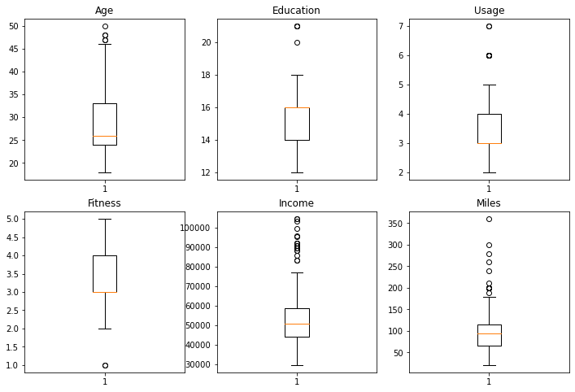

```python
#Create boxplots for numerical variables which display utlaiers outside +-1.5*IQR
#NOTE: The technique is same as that presented in content video on Outliers
num_cols = ['Age','Education','Usage','Fitness','Income','Miles']
plt.figure(figsize = (12,8))

for i, variable in enumerate(num_cols):
    plt.subplot(2,3,i+1)
    plt.boxplot(cardio[variable],whis=1.5)
    plt.tight_layout
    plt.title(variable)

plt.show()
```

## Initial Observations (need for further observation)

- Significant outliers for Income and Miles
- Age: Spread (the spread of the lower 50% is significantly smaller than for the upper 50%; three outliers between 45 and 50
- Education: Median and 3rd Quartile (Q3) are equal. Two outliers (20 and 21 years of education)
- Usage: 1st Quartile (Q1) and Median are equal; two outliers (6 and 7)
- Fitness: Low outlier (1); Q1 and Median are equal.
- Income: Significant number of outliers (data significantly skewed right)
- Miles: Significant number of Outliers (data significantly skewed)

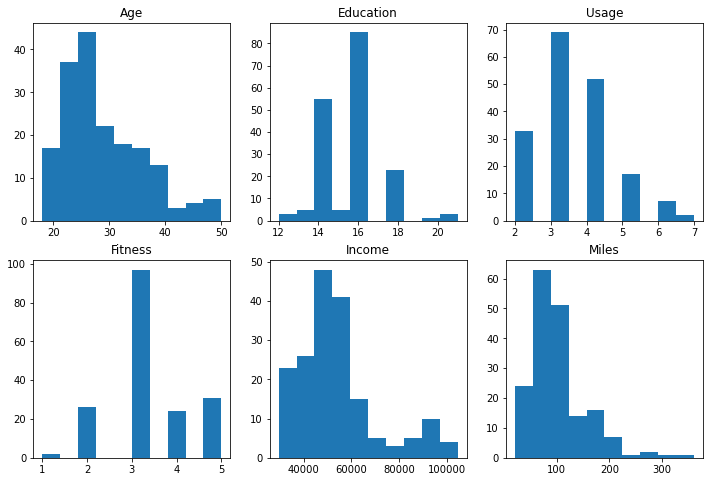

```python
#Create histograms for numerical variables
#NOTE: The technique is same as that presented in content video on Outliers
num_cols = ['Age','Education','Usage','Fitness','Income','Miles']
plt.figure(figsize = (12,8))

for i, variable in enumerate(num_cols):
    plt.subplot(2,3,i+1)
    plt.hist(cardio[variable])
    plt.tight_layout
    plt.title(variable)

plt.show()
```

## Inital Observations (need for further investigation)

- Age: data is skewed right; The age of most customers centers aroung 22-27;
- Education: Education is bimodal (or multi-model); two primary modes at 16 and 14 years of education; a third mode is 18 years of education.
  - **Mode is the best measure of centrality for Education**
- Usage: Usage is also skewed right; with Mode at 3 days per week; Centrality of data is 3 days per week with outliers of 6 or 7 days per week.
- Fitness: Mode of Fitness data is 3; Center of data is 3; 1 is an outlier with most customers ranking their Fitness level at 3 or better.
- Income: Centrality occurs around 55,000; data is skewed right with outliers at the high end of data
- Miles: Centrality of data is around 80-110; data is skewed right;

## Observations on Age

Young people (people between 18 and 33 years of age (Q3)) are more likely to buy a treadmill.Only 25% of the treadmill purchases were made by people over 33.

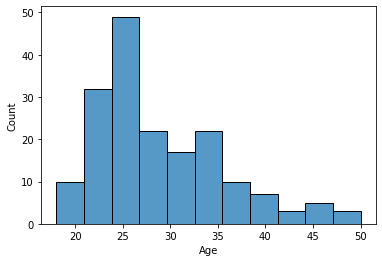

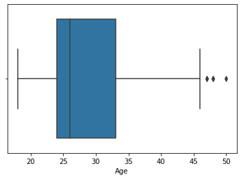

```
count    180.000000
mean      28.788889
std        6.943498
min       18.000000
25%       24.000000
50%       26.000000
75%       33.000000
max       50.000000
Name: Age, dtype: float64
```

```python
#Create boxplot and histogram AND display description statistics for 'Age'
sns.histplot(data = cardio, x='Age')
plt.show()
sns.boxplot(data = cardio, x='Age')
plt.show()
cardio['Age'].describe().T
```

## Observations on Education

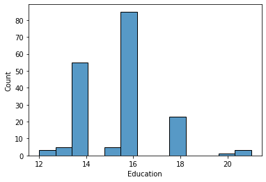

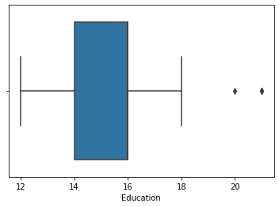

```
count    180.000000
mean      15.572222
std        1.617055
min       12.000000
25%       14.000000
50%       16.000000
75%       16.000000
max       21.000000
Name: Education, dtype: float64
```

```python
#Create boxplot and histogram AND display description statistics for 'Education'
sns.histplot(data = cardio, x='Education')
plt.show()
sns.boxplot(data = cardio, x='Education')
plt.show()
cardio['Education'].describe().T
```

## Observations on Usage

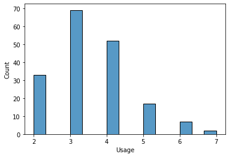

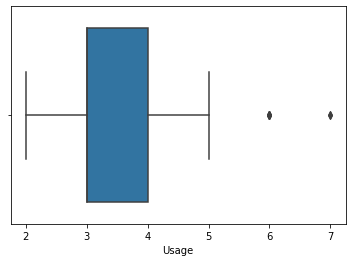

```
count    180.000000
mean       3.455556
std        1.084797
min        2.000000
25%        3.000000
50%        3.000000
75%        4.000000
max        7.000000
Name: Usage, dtype: float64
```

```python
#Create boxplot and histogram AND display description statistics for 'Usage'
sns.histplot(data = cardio, x='Usage')
plt.show()
sns.boxplot(data = cardio, x='Usage')
plt.show()
cardio['Usage'].describe().T
```

## Observations on Fitness

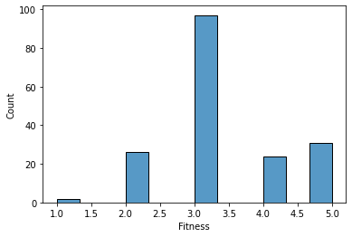

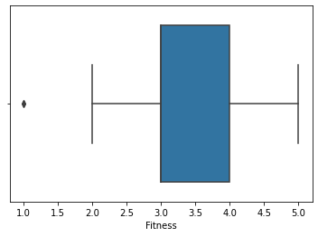

```
count    180.000000
mean       3.311111
std        0.958869
min        1.000000
25%        3.000000
50%        3.000000
75%        4.000000
max        5.000000
Name: Fitness, dtype: float64
```

```python
#Create boxplot and histogram AND display description statistics for 'Fitness'
sns.histplot(data = cardio, x='Fitness')
plt.show()
sns.boxplot(data = cardio, x='Fitness')
plt.show()
cardio['Fitness'].describe().T
```

## Observations on Income

Income centers around 50000 - 53000; This data however is affected by outliers and is significantly skewed right. To view this data more fully, income needs to be evaluated at a higher level. A significant question to as is "what is the income distribution of the population of both Treadmill buyers and non - treadmill buyers" to see if there is a level at which the purchase of a treadmill by a member of the population is more likely. From this data alone, one would surmise that an income of at least 30,000 is need before an individual would consider a purchase of a Treadmill. An income of at least 44,000 makes it more likely for an individual to consider a purchase of a treadmill.

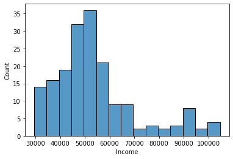

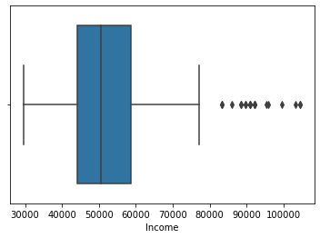

```
count       180.000000
mean      53719.577778
std       16506.684226
min       29562.000000
25%       44058.750000
50%       50596.500000
75%       58668.000000
max      104581.000000
Name: Income, dtype: float64
```

```python
#Create boxplot and histogram AND display description statistics for 'Income'
sns.histplot(data = cardio, x='Income')
plt.show()
sns.boxplot(data = cardio, x='Income')
plt.show()
cardio['Income'].describe().T
```

## Observations on Miles

Miles data is significantly skewed right with outliers occurring at or above approximately 180 miles.the center of the data is therefore somewhere near the mean (approximately 103) and the median (94). Placing central tendancey at or near the median is more likely given the skewness of the data. Most customers intend to use the treadmill for around 94 miles or within the IQR (66 to 114 miles)

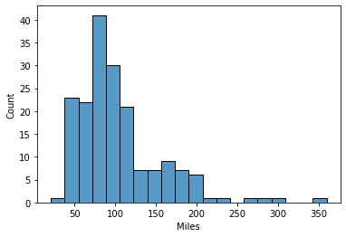

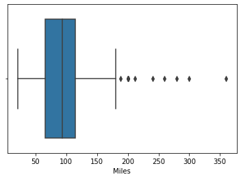

```
count    180.000000
mean     103.194444
std       51.863605
min       21.000000
25%       66.000000
50%       94.000000
75%      114.750000
max      360.000000
Name: Miles, dtype: float64
```

```python
#Create boxplot and histogram AND display description statistics for 'Miles'
sns.histplot(data = cardio, x='Miles')
plt.show()
sns.boxplot(data = cardio, x='Miles')
plt.show()
cardio['Miles'].describe().T
```

## Observations on Product

4/9 Treadmill products were TM195 (44.4%); 1/3 treadmill products were TM498(33.3%); 2/9 treadmill products sold were TM798 (22.2%) Nearly half of the products purchased by customers were TM195.

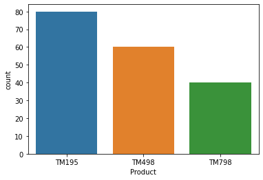

```
TM195    44.444444
TM498    33.333333
TM798    22.222222
Name: Product, dtype: float64
```

```python
#Display Bar chart and corresponding value count percentages for "Product"
sns.countplot(data=cardio, x='Product')
plt.show()
Product_count=cardio['Product'].value_counts(normalize=True).sort_index()
print(Product_count*100)
```

## Observations on Gender

More men than woman (57.7% compared to 42.2%, respectively) purchased Treadmills.

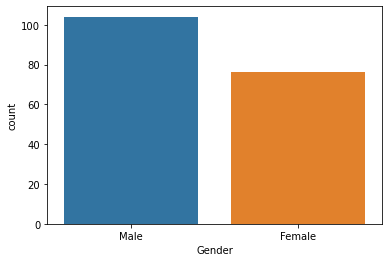

```
Female    42.222222
Male      57.777778
Name: Gender, dtype: float64
```

```python
#Display Bar chart and corresponding value count percentages for "Gender"
sns.countplot(data=cardio, x='Gender')
plt.show()
Product_count=cardio['Gender'].value_counts(normalize=True).sort_index()
print(Product_count*100)
```

## Observations on Marital Status

59.4% of customers are Married (Partnered) versus 40.6% are single. Parnered customers are more likely than single customers.

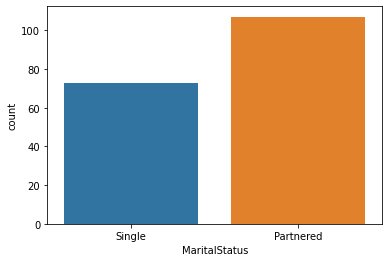

```
Partnered    59.444444
Single       40.555556
Name: MaritalStatus, dtype: float64
```

```python
#Display Bar chart and corresponding value count percentages for "MaritalStatus"
sns.countplot(data=cardio, x='MaritalStatus')
plt.show()
Product_count=cardio['MaritalStatus'].value_counts(normalize=True).sort_index()
print(Product_count*100)
```

# Bivariate Analysis

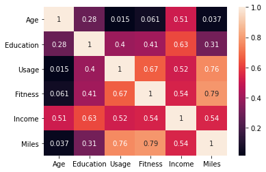

```python
#Generate Correlation heatmap to view variable relationships per Pearson coefficient
sns.heatmap(data = cardio[['Age','Education','Usage','Fitness','Income','Miles']].corr(),annot=True);
```

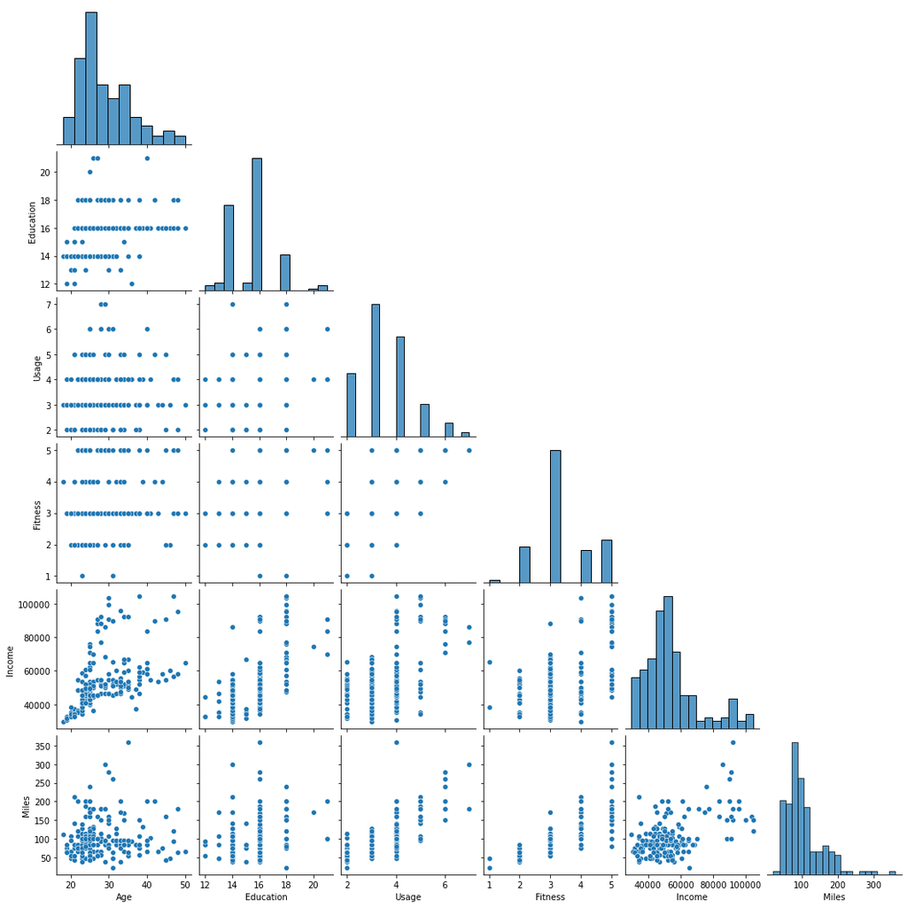

```python
#Generate Pairplot of Numerical data
sns.pairplot(data = cardio[['Age','Education','Usage','Fitness','Income','Miles']],corner=True);
```

## Observations:

Potential relationships to explore

- Relationship between Age and Income (and categorical variables)
- Relationship between Education and Income (and categorical variables)
- Relationship between Usage and Income (and categorical variables)
- Relationship between Miles and Age and Usage (and categorical variables)
- Relationship between Miles and Fitness (and Categorical variables)

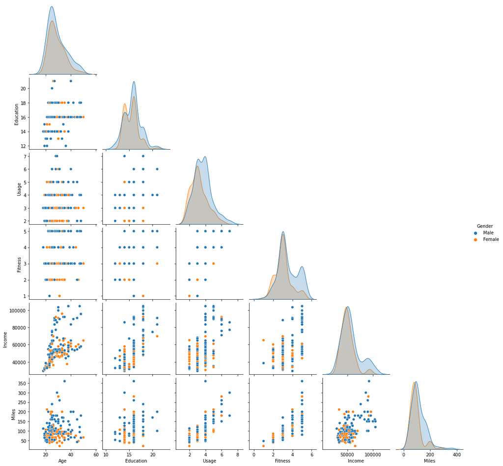

```python
#Add Gender categorical variable to numerical variables pairplot
sns.pairplot(data = cardio, vars =['Age','Education','Usage','Fitness','Income','Miles'],hue = 'Gender',corner=True);
```

## Observations (Numerical variables and Categorical Variable - Gender

Further Observation needed:

- Male Usage versus female usage
- Male Fitness and Female Fitness
- Age, Income and Gender
- Income, Fitness and Gender
- Income, Usage and Gender

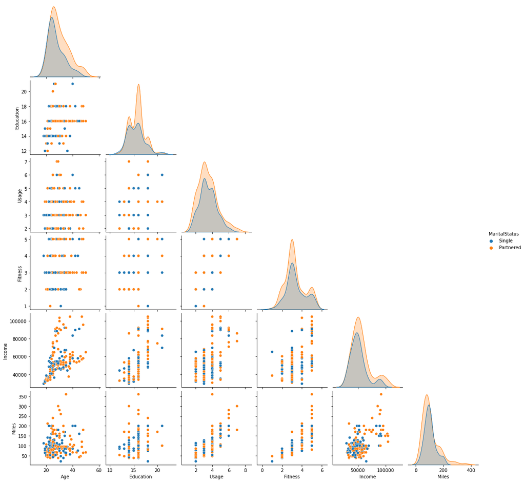

```python
#Add Marital Status categorical variable to numerical variables pairplot
sns.pairplot(data = cardio, vars =['Age','Education','Usage','Fitness','Income','Miles'],hue = 'MaritalStatus',corner=True);
```

## Observations

Potential relationships exist between the following:

- Income, Age and marital status
- Education and Marital status
- Age and Gender

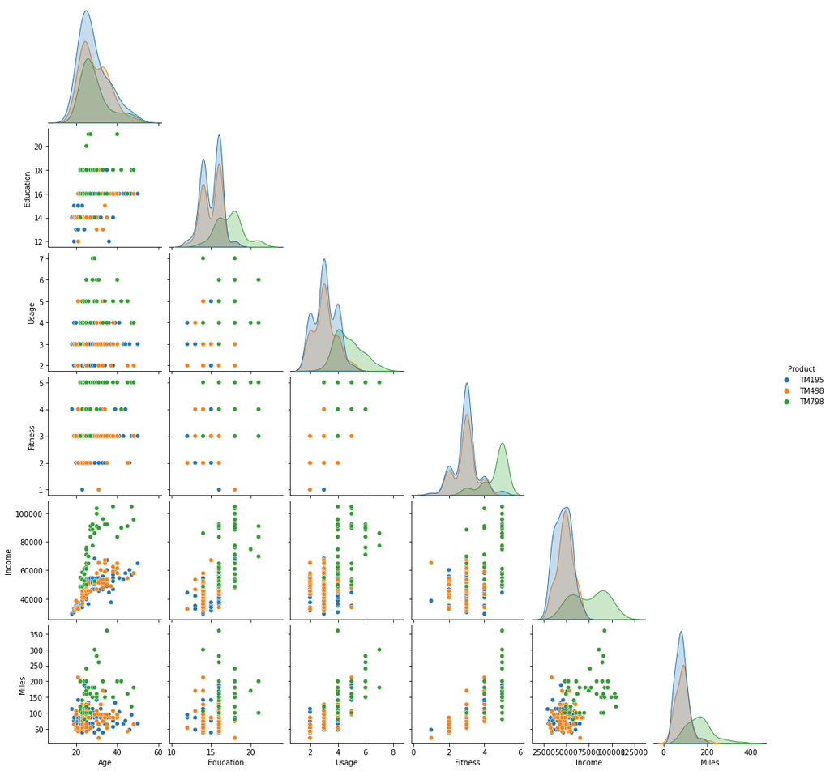

```python
#Display correlation plots for numerical variables with emphasis of product
sns.pairplot(data = cardio, vars =['Age','Education','Usage','Fitness','Income','Miles'],hue = 'Product',corner=True);
```

## Observations

Potential relationships to explore (not an exhaustive list)

- Education and product
- Usage and Product
- Fitness and Product
- Income and Product
- Miles and Product
- Miles, Income and Product
- Miles, Age and Product
- Income, Age and Product
- Income, Education and Product
- Miles, Usage and Product
- Usage, Age and Product
- Fitness, Age and product

## Explore relationships between Numerical and Categorical variables

### Age, Product and Gender

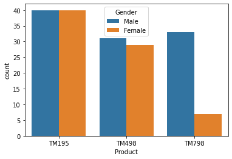

```python
#Display bar chart for Number of Males and females who purchase a specific category of Treadmill.
sns.countplot(data=cardio, x='Product', hue= 'Gender')
```